# Title: Automatic Detection of Pitch Types in Real Time for MLB Broadcasts

## Introduction

The goal of this project is to build a model that can automatically identify what type of pitch Kevin Gausman throws in real time. This system would help display the pitch type instantly during live games — both on stadium screens and on TV broadcasts. The model uses data on the pitch’s characteristics, things like velocity, spin rate, and movement, to predict whether it’s a fastball (FF), splitter (FS), slider (SL), or sinker (SI).

Real-time pitch classification is valuable for fans and broadcasters because the experience becomes so much more engaging. Additionally, it removes the need for someone to manually label pitches during a game, saving money.

For this, historical MLB pitch-by-pitch data that includes features such as release speed, spin rate, and pitch movement (pfx_x and pfx_z), along with the actual pitch type was used. The original source of the data is Statcast. Specifically, the pybaseball package was used to interface with Statcast Search, which is part of Baseball Savant. Each observation contains information about a single pitch thrown by Kevin Gausman in either 2024 (train data) or 2025 (test data) during an MLB regular season game. The goal was to train a model that’s not only accurate but also fast enough to make predictions almost instantly after each pitch is thrown. This report walks through the data, the model-building process, and how well the final model performs—and evaluates whether it could realistically be used during live broadcasts.

## Methods

To build the pitch classification model, it was necessary to start by exploring Kevin Gausman’s pitch data. Each record included variables like release speed, release spin rate, and pitch movement measurements (pfx_x and pfx_z), along with the pitch type label. The goal was to use these features to predict whether a pitch was a fastball (FF), splitter (FS), slider (SL), or sinker (SI).

Data Exploration: For this part, looking at the average velocity and spin rate for each pitch type was an imperative step in understanding how they differ. Figure 1 shows the differences in both velocity and spin rate across Kevin Gausman’s four pitch types. The fastball (FF) has the highest velocity (around 94 mph), while the slider (SL) is the slowest at about 83 mph. The fastball and slider also have the highest spin rates, whereas the splitter (FS) has the lowest. These patterns highlight why features like velocity and spin rate are used as predictors for distinguishing between pitch types. Based on the data, the following numeric features for the model were selected: release_speed, release_spin_rate, pfx_x, and pfx_z as well as the batter’s stance (stand) for the categorical feature.

Next up, the data needed to be preprocessed. A preprocessing pipeline needed to be built to handle missing values and prepare the data to be modeled. For the numeric features, a SimpleImputer and a StandardScaler used often to normalize data was used. For the one categorical feature used, a SimpleImputer and a OneHotEncoder to convert categories into numeric form was input into the code. Then, these steps combined into a ColumnTransformer that worked with both numeric and categorical data at once.

Model Building: The next part was the model building. To classify the pitches, a K-Nearest Neighbors (KNN) classifier was used. After testing different neighbor values, the k value was set to k = 18, which gave strong performance on the validation data. KNN was chosen because of how simple and interpretable is is. It is also fast enough for real-time predictions once it has been properly trained. The model was wrapped into a single pipeline, which included both preprocessing and the classifier. This made the workflow efficient and easy to reuse for other pitchers. The data was also split into training and test sets as mentioned in the introduction section. After fitting the model on the training set, it was evaluated on the test set in order to measure how well it could predict on unseen pitches. The final model generated a test accuracy of 0.987 which is a high level of accuracy. Lastly, the model was saved using joblib so it could be reused if needed.

### Data

For this part, looking at the average velocity and spin rate for each pitch type was an imperative step in understanding how they differ. Figure 1 shows the differences in both velocity and spin rate across Kevin Gausman’s four pitch types. The fastball (FF) has the highest velocity (around 94 mph), while the slider (SL) is the slowest at about 83 mph. The fastball and slider also have the highest spin rates, whereas the splitter (FS) has the lowest. These patterns highlight why features like velocity and spin rate are used as predictors for distinguishing between pitch types. Based on the data, the following numeric features for the model were selected: release_speed, release_spin_rate, pfx_x, and pfx_z as well as the batter’s stance (stand) for the categorical feature.

Next up, the data needed to be preprocessed. A preprocessing pipeline needed to be built to handle missing values and prepare the data to be modeled. For the numeric features, a SimpleImputer and a StandardScaler used often to normalize data was used. For the one categorical feature used, a SimpleImputer and a OneHotEncoder to convert categories into numeric form was input into the code. Then, these steps combined into a ColumnTransformer that worked with both numeric and categorical data at once.

```
Velocity by Pitch Type:
                 mean       std
pitch_type
FF          93.957527  1.700911
FS          85.969552  1.821758
SI          93.310497  1.739876
SL          82.747917  1.864128
```

```
Spin Rate by Pitch Type:
                   mean         std
pitch_type
FF          2287.098118  101.983970
FS          1764.038582  177.469770
SI          2189.022099  113.026494
SL          2239.435146   96.452687
```

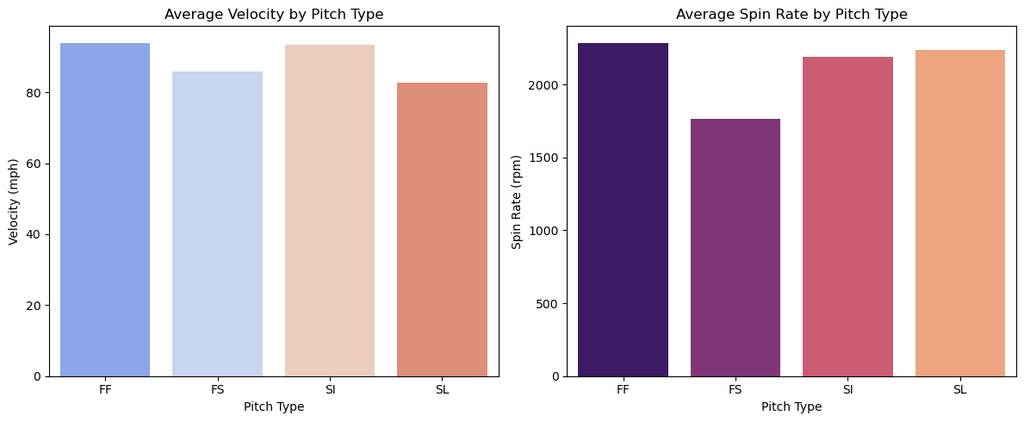

### Models

The next part was the model building. To classify the pitches, a K-Nearest Neighbors (KNN) classifier was used. After testing different neighbor values, the k value was set to k = 18, which gave strong performance on the validation data. KNN was chosen because of how simple and interpretable is is. It is also fast enough for real-time predictions once it has been properly trained. The model was wrapped into a single pipeline, which included both preprocessing and the classifier. This made the workflow efficient and easy to reuse for other pitchers. The data was also split into training and test sets as mentioned in the introduction section. After fitting the model on the training set, it was evaluated on the test set in order to measure how well it could predict on unseen pitches. The final model generated a test accuracy of 0.987 which is a high level of accuracy. Lastly, the model was saved using joblib so it could be reused if needed.

## Results

```
Test Accuracy: 0.9867109634551495
```

[figure not shown]

```
['pitches.joblib']
```

## Discussion

All in all, the model was successful in predicting Kevin Gausman’s pitch types, with a test accuracy of 98.7%! This strong performance means that the model could be a tool for automatically identifying pitches during live broadcasts - saving money and effort. The KNN classifier is ideal for real-time use. Once the data from tracking systems is put into the model, it will make predictions almost instantly. In turn, this would allow broadcasters to display the pitch type on-screen all of a sudden!

However, there are limitations to note. First, the model was trained only on one player’s data. While this makes it accurate for him, it will not perform well for other pitchers because pitch styles and speeds would be different. To make that possible (make it scalable), the same process would have to be applied to each pitcher, or a generalized model could be created using data from multiple pitchers. Second, the dataset showed an imbalance - fastballs and splitters were more common than sliders and sinkers - which could have the effect of biasing the model toward the more frequent pitch types. Additionally, future improvements could be made. This could include testing other methods or including cross-validation to make sure there is consistency and exploring additional features like pitch release angle or vertical break to further tune the accuracy of the model. In conclusion, the KNN model is a strong model for automated pitch classification. It’s accurate, efficient, and practical for broadcast use, and with even more training across different kinds of pitchers, it could easily scale to support league-wide use.